# Mapping Report

# Importing Data

The `lctools` package provides The `GR.Municipalities` data. Which is a `SpatialPolygonDataFrame` object. The `data` slot contains the demographic information of the 325 municipalities of Greece.

```r
data(GR.Municipalities)
data_by_Municipality <- GR.Municipalities@data
```

# Classes creation for Unemployment Rate

We will use `cut` function to create 6 classes of unemployment rate.

```r
k = 6
data_by_Municipality$UnemrT_cluster <- cut(data_by_Municipality$UnemrT01, breaks = k)
table(data_by_Municipality$UnemrT_cluster)
```

```
##
## (0.331,3.57]   (3.57,6.8]     (6.8,10]    (10,13.2]  (13.2,16.5]  (16.5,19.7]
##           52          187           57           19            7            3
```

However, the classes breaks provided by the `cut` function are not rounded to integers. We will use some manipulations to round breaks to the nearest integer.

```r
classes_bandwidth <- group_by(data_by_Municipality, UnemrT_cluster) %>%
    summarise(min_ban = round(min(UnemrT01)),
              max_ban = round(max(UnemrT01)))

classes_bandwidth <- c(classes_bandwidth$min_ban, classes_bandwidth$max_ban[k])
classes_bandwidth
```

```
## [1]  0  4  7 10 13 17 20
```

Next, we construct the labels for the classes in the form : $[x,x+1[$

```r
class_labels <- paste0("[", classes_bandwidth, ",", lead(classes_bandwidth), "[")
class_labels <- class_labels[-(k+1)]
class_labels
```

```
## [1] "[0,4["   "[4,7["   "[7,10["  "[10,13[" "[13,17[" "[17,20["
```

We will assign municipalities to the new classes according to the new breaks we have constructed.

```r
#Function serving to assign unemployment rate to corresponding class
cluster_fun <- function(x, Bands, Labels) {
  k = length(Bands)
  for (i in 2:k) {
    if (x >= Bands[i-1] & x < Bands[i])
      return(Labels[i-1])
  }
}

data_by_Municipality <- rowwise(data_by_Municipality) %>%
  mutate(class_unemr = cluster_fun(UnemrT01, classes_bandwidth, class_labels),
         class_unemr = factor(class_unemr, levels = class_labels))

head(data_by_Municipality[c(1:4,11,16)])
```

```
## Source: local data frame [6 x 6]
## Groups: <by row>
##
## # A tibble: 6 x 6
##   OBJECTID       X        Y Name              UnemrT01 class_unemr
##      <int>   <dbl>    <dbl> <fct>                <dbl> <fct>
## 1        1 616259. 4551127. KOMOTINIS             5.22 [4,7[
## 2        2 644783. 4561364. ARRIANON              2.15 [0,4[
## 3        3 602101. 4555689. IASMOU                6.06 [4,7[
## 4        4 633712. 4539548. MARONEIAS - SAPON     7.42 [7,10[
## 5        5 517831. 4572544. DRAMAS               10.9  [10,13[
## 6        6 520765. 4546141. DOXATOU              12.1  [10,13[
```

# Exploring Unemployment Rate classes

Before going to map creation, let’s explore the distribution of unemployment rates within classes.

```r
#Custom theme to use for coming plots
Custom_theme <- theme_bw()+
  theme(panel.grid.minor = element_blank(),
        panel.grid.major.x = element_blank(),
        legend.position = "None")
```

First, let’s visualize how many municipalites in each group using bar plot

```r
table(data_by_Municipality$class_unemr)
```

```
##
##   [0,4[   [4,7[  [7,10[ [10,13[ [13,17[ [17,20[
##      72     172      52      18       9       2
```

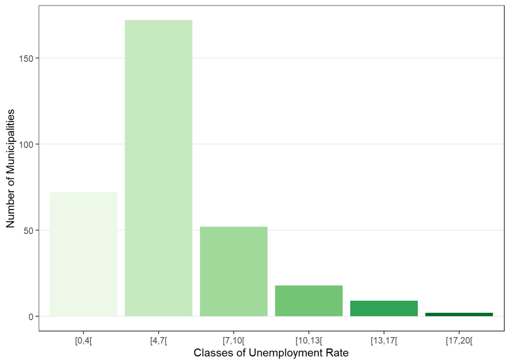

```r
ggplot(data_by_Municipality, aes(x = class_unemr, fill = class_unemr))+
  geom_bar()+
  Custom_theme+
  scale_fill_brewer(palette = "Greens")+
  labs(x = "Classes of Unemployment Rate",
       y = "Number of Municipalities")
```

More than half of municipalities have unemployment rates between 4% and 7%. Fewer municipalites have unemployment rates between 13% and 20%.

Boxplots help visualising distribution of unemployment rate within each class.

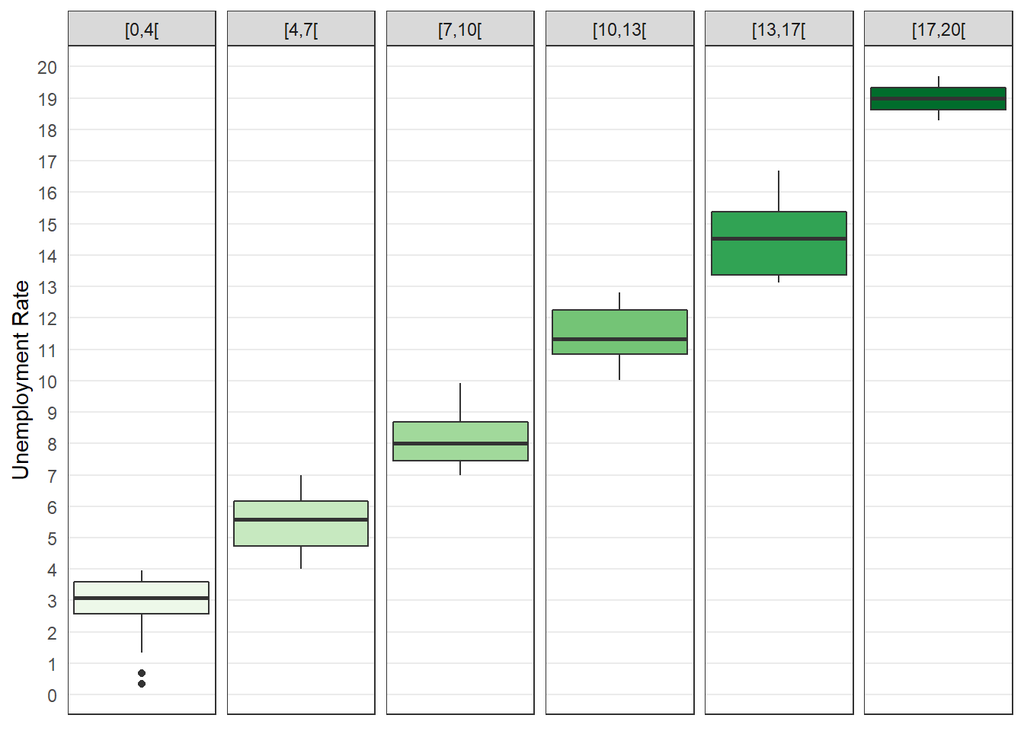

```r
ggplot(data_by_Municipality, aes(fill = class_unemr))+
  geom_boxplot(aes(y = UnemrT01))+
  scale_y_continuous(breaks = 0:20)+
  facet_grid(~class_unemr, scale = "free")+
  Custom_theme +
  scale_fill_brewer(palette = "Greens")+
  theme(axis.text.x = element_blank(),
        axis.ticks = element_blank())+
  labs(y = "Unemployment Rate")
```

# Data preparation for mapping

Preparing data for mapping includes assigning polygons in the `sp` object to our data. So that each municipality is represented with a finite number of segments connected to form a closed polygon .

```r
map_data <- fortify(GR.Municipalities, region = "OBJECTID") %>%
  mutate(id = as.numeric(id)) %>%
  left_join(data_by_Municipality, by = c("id" = "OBJECTID"))
```

# Mapping

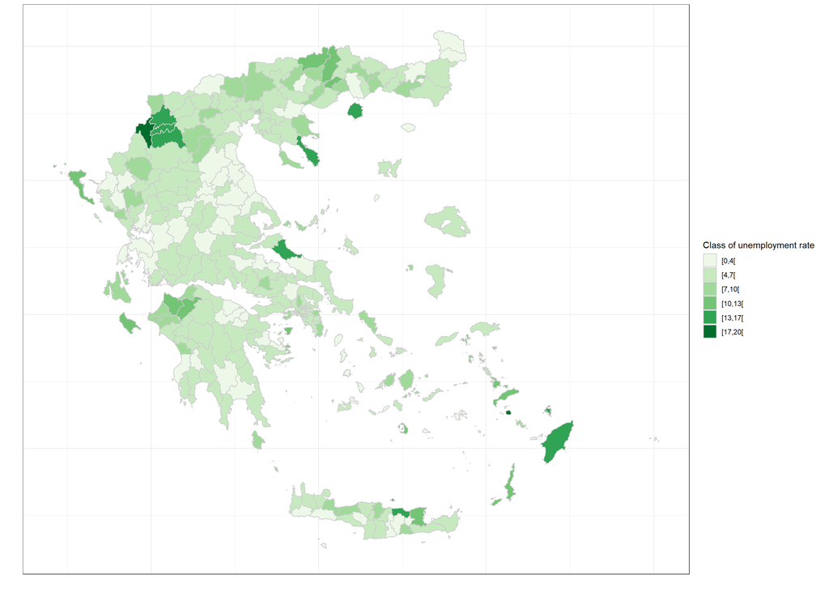

```r
map_data %>%
  ggplot(aes(long, lat, group = group)) +
  geom_polygon(color = "gray80", aes(fill = class_unemr)) +
  scale_fill_brewer(palette = "Greens") +
  coord_equal() +
  theme_bw() +
  theme(axis.text = element_blank(), axis.ticks = element_blank()) +
  labs(x= "", y= "", fill= "Class of unemployment rate")
```